# Estimating longevity distributions

Author

Daniel van Denderen & Jan-Geert Hiddink

## Introduction

This step demonstrates how to use benthic sampling and trait data to estimate a biomass-longevity distribution.

## Install and Load Required Libraries

We first load again the libraries and custom functions.

```r
# Load necessary libraries and custom functions
source("Libraries_needed.R")
source("Functions.R")
```

## Load and Process Benthic Data

The benthic data comes from a Dutch monitoring program carried out in 2007. Samples were collected using a box corer, with one sample taken at each location. Because the number of stations is relatively low, the reliability of the predictions is limited. The analysis we aim to perform is therefore mainly illustrative and serves as an example.

The benthic data is primarily identified at the species level. Trait information on longevity is linked to these species observations at the genus level. Longevity is categorized into four trait modalities: less than 1 year, 1–3 years, 3–10 years, and more than 10 years.

```r
# Load benthic data
datBen <- read.csv(file="data/Benthic data/Benthic_Data_tutorial.csv",
                   header=TRUE, sep=";")
head(datBen)
```

```
  sample_ID                       Nomen Merge_to_traits sample_m2      Biomass
1 BREEVTN02 Bathyporeia guilliamsoniana     BATHYPOREIA     0.078  0.004378528
2 BREEVTN02                 Callianassa     CALLIANASSA     0.078  0.083641379
3 BREEVTN02     Callianassa subterranea     CALLIANASSA     0.078  2.559009246
4 BREEVTN02               Corbula gibba         CORBULA     0.078  0.014490566
5 BREEVTN02      Corystes cassivelaunus        CORYSTES     0.078  3.187260085
6 BREEVTN02      Echinocardium cordatum   ECHINOCARDIUM     0.078 18.402974690
    L1 L1_3     L3_10       L10
1 0.75 0.25 0.0000000 0.0000000
2 0.00 1.00 0.0000000 0.0000000
3 0.00 1.00 0.0000000 0.0000000
4 0.00 1.00 0.0000000 0.0000000
5 0.00 0.00 1.0000000 0.0000000
6 0.00 0.00 0.6666667 0.3333333
```

```r
# multiply biomass with fuzzy-coded traits
datBen[,6:9] <- datBen$Biomass * datBen[,6:9] #get Longevity categories (col. 6:9)

# Summarize per sample ID and calculate fractions
nC <- c("Biomass","L1","L1_3","L3_10","L10")
statdat <- aggregate(. ~ sample_ID,
                     data = datBen[, c("sample_ID", nC)],
                     FUN = function(x) sum(x, na.rm = TRUE))
nC <- nC[-1]
statdat[,nC] <- statdat[,nC] / statdat$Biomass

# load environmental information per station
statEnv <- read.csv(file="data/Benthic data/Env_Data_tutorial.csv",
                    header=TRUE, sep=",")
statEnv <- cbind(statEnv, statdat[match(statEnv$ID, statdat$sample_ID), nC])
head(statEnv)
```

```
         ID replicate   poslon   poslat SUR_SWEPT_KM2 SUBSUR_SWEPT_KM2 Depth
1 BREEVTN02      2007 3.305833 53.52500     1.7375235        1.5104170 35.29
2 BREEVTN03      2007 4.442222 53.18778     0.1532636        0.1499495 27.17
3 BREEVTN07      2007 3.841667 52.76111     2.3520490        2.3154352 29.32
4 BREEVTN08      2007 3.521667 53.28333     0.7601260        0.7179096 31.65
5 BREEVTN12      2007 3.288333 52.83667     3.7365597        2.6404710 34.37
6 BREEVTN14      2007 3.203333 52.46194     2.0325753        1.8513034 35.16
  Bedstress                                MSFDhab           L1        L1_3
1     0.133             Offshore circalittoral mud 0.0001530191 0.110971841
2     0.396          Circalittoral coarse sediment 0.0000000000 0.157803692
3     0.635 Offshore circalittoral coarse sediment 0.0058561908 0.068939395
4     0.208                     Circalittoral sand 0.0002252294 0.184730322
5     0.628            Offshore circalittoral sand 0.0013614869 0.002286858
6     0.969            Offshore circalittoral sand 0.0124476376 0.125960711
       L3_10       L10
1 0.64227195 0.2466032
2 0.84219631 0.0000000
3 0.92520441 0.0000000
4 0.56950722 0.2455372
5 0.06169634 0.9346553
6 0.86159165 0.0000000
```

We plot the stations within the grid defined in Step 1. As you can see, the number of stations is limited (but adequate to illustrate the methodology).

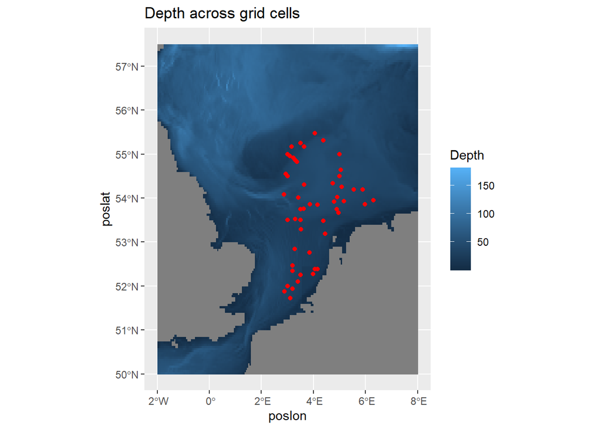

```r
load("model/Region_grid.RData")

ggplot() +
  geom_sf(data = grid_sf, aes(col = Depth, fill=Depth)) +
  ggtitle("Depth across grid cells") +
  geom_point(data=statEnv, aes(x=poslon, y=poslat),col="red")
```

## Example: Longevity and biomass Distribution

First, we run through an example with three stations that differ in their distribution of biomass among the four longevity modalities.

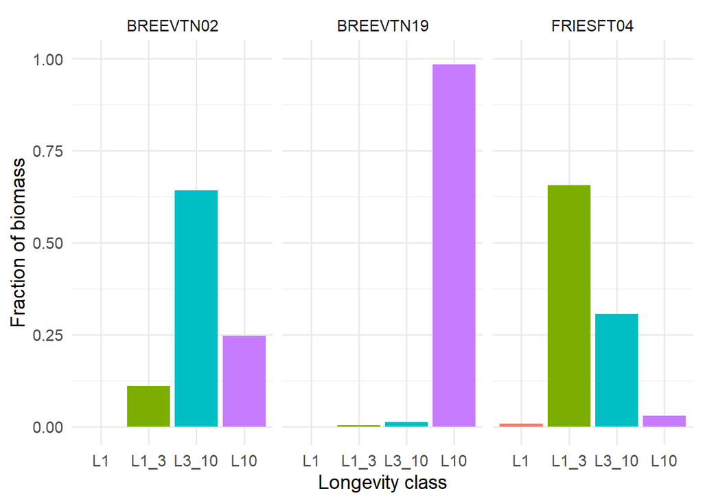

```r
# select three stations (row 1, 10 and 25)
idx <- c(1, 10, 25)

# extract the relevant longevity columns for the three rows
bar_data <- statEnv[idx, c("ID", "L1", "L1_3", "L3_10", "L10")]

# reshape from wide to long
bar_data_long <- reshape(bar_data,
                         varying = c("L1", "L1_3", "L3_10", "L10"),
                         v.names = "Fraction",
                         timevar = "Longevity_class",
                         times = c("L1", "L1_3", "L3_10", "L10"),
                         direction = "long")

# enforce correct order of bars
bar_data_long$Longevity_class <- factor(
  bar_data_long$Longevity_class,
  levels = c("L1", "L1_3", "L3_10", "L10")
)

# plot with ggplot
ggplot(bar_data_long,
       aes(x = Longevity_class, y = Fraction, fill = Longevity_class)) +
  geom_col() +
  facet_wrap(~ ID, nrow = 1) +
  scale_y_continuous(limits = c(0, 1)) +
  labs(x = "Longevity class", y = "Fraction of biomass") +
  theme_minimal(base_size = 14) +
  theme(legend.position = "none")
```

Question: Which sampling location is most sensitive to bottom fishing disturbance? Which one is the least sensitive?

This categorical information can be transformed into a continuous distribution by estimating cumulative biomass as a function of longevity.

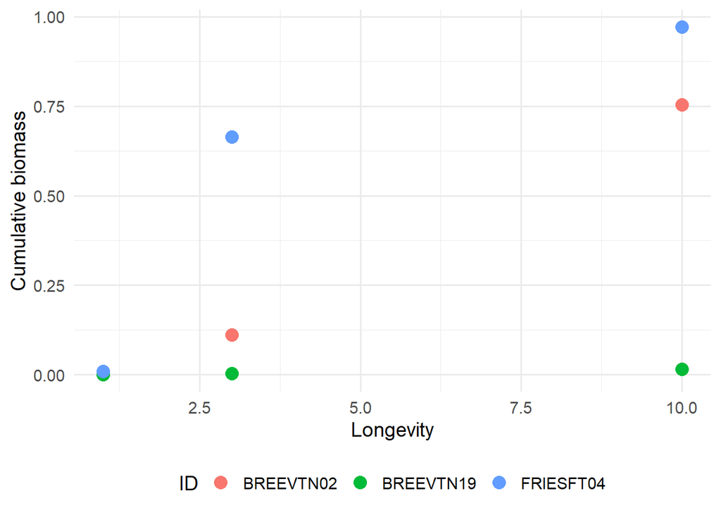

```r
# Select sample indices for example
idx <- c(1, 10, 25)

# Build cumulative biomass example
example <- data.frame(
  Cumb = c(statEnv[idx,10],
           statEnv[idx,10] + statEnv[idx,11],
           statEnv[idx,10] + statEnv[idx,11] + statEnv[idx,12]),
  Longevity = c(1,1,1,3,3,3,10,10,10),
  ID = rep(statEnv$ID[idx], 3)
)

# First plot: linear x-axis
p1 <- ggplot(example, aes(x = Longevity, y = Cumb, color = ID)) +
  geom_point(size = 4) +
  labs(x = "Longevity", y = "Cumulative biomass") +
  theme_minimal(base_size = 14) +
  theme(legend.position = "bottom")

p1
```

The cumulative distributions can be modeled by assuming that the biomass proportion at each station follows a sigmoidal (logistic) function of log-transformed longevity, starting at 0 and approaching 1 as longevity increases. This is done using a type of statistical model with a binomial distribution, which is suitable for modeling proportions.

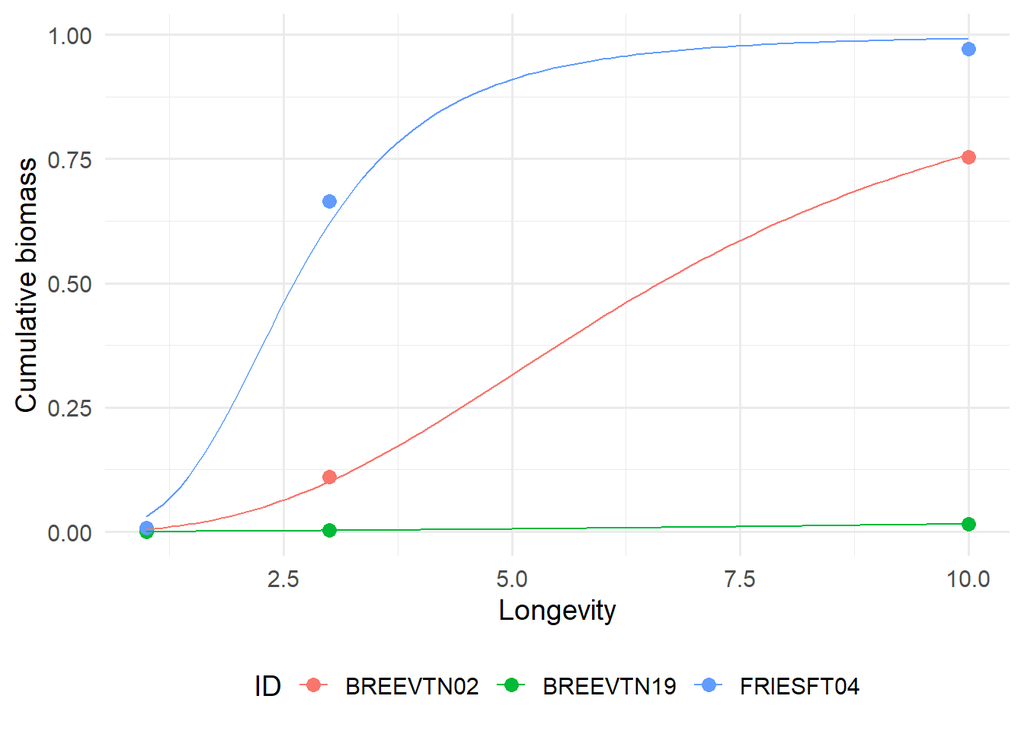

```r
# Log-transform predictor
example <- example %>% mutate(lx = log(Longevity))

# Fit binomial GLM with interaction: lx * ID
mod1 <- glm(Cumb ~ lx * ID, family = "binomial", data = example)

# Create prediction grid for all IDs
pred_data <- expand.grid(
                  Longevity = seq(min(example$Longevity),
                                  max(example$Longevity),
                  length.out = 100), ID = unique(example$ID))
pred_data$lx <- log(pred_data$Longevity)

# Get predicted values
pred_data$y_pred <- predict(mod1, newdata = pred_data, type = "response")

# Plot points and per-ID lines
ggplot(example, aes(x = Longevity, y = Cumb, color = ID)) +
  geom_point(size = 3) +
  geom_line(data = pred_data, aes(x = Longevity, y = y_pred, color = ID)) +
  labs(x = "Longevity", y = "Cumulative biomass") +
  theme_minimal(base_size = 14) +
  theme(legend.position = "bottom")
```

## Longevity-biomass distributions

The goal of the statistical model is to estimate which environmental conditions drive variation in the cumulative biomass-longevity distributions. For example, if benthic fauna tend to be longer-lived in deeper waters, we want to quantify this relationship to predict how longevity, and therefore sensitivity, varies with depth.

The statistical model we are typically using has the following structure:

- A generalized linear mixed-effects model
- Longevity is log-transformed
- Binomial family
- Sampling station is a random variable
- Year and replicate, if available, are random variables

For this example, we examine three environmental data layers: depth, sediment type (categorical), and bed shear stress. To obtain sediment type information, we use the MSFD broad habitat type classification, which is derived from both depth and sediment characteristics. We do not use the depth information from the MSFD classification, since depth can also be presented as a continuous variable, which is generally more suitable for model fitting.

```r
# Assign sediment categories from MSFD broad habitat types
table(statEnv$MSFDhab)
```

```
         Circalittoral coarse sediment                      Circalittoral mud
                                     1                                      1
                    Circalittoral sand          Infralittoral coarse sediment
                                    10                                      1
                    Infralittoral sand Offshore circalittoral coarse sediment
                                     1                                      1
            Offshore circalittoral mud            Offshore circalittoral sand
                                    10                                     27
```

```r
id_mud <- c("Circalittoral mud","Offshore circalittoral mud")
statEnv$sediment <- ifelse(statEnv$MSFDhab %in% id_mud, "Mud", "Coarse_Sand")

# Prepare full dataset for mixed model
ID        <- rep(statEnv$ID, 3)
Sediment  <- rep(statEnv$sediment, 3)
Depth     <- rep(statEnv$Depth, 3)
Stress    <- log(rep(statEnv$Bedstress, 3))
Cumb      <- c(statEnv$L1, statEnv$L1 + statEnv$L1_3,
               statEnv$L1 + statEnv$L1_3 + statEnv$L3_10)
Longevity <- c(rep(1, nrow(statEnv)), rep(3, nrow(statEnv)),
               rep(10, nrow(statEnv)))

fulldat <- data.frame(ID, Sediment, Depth, Cumb, Longevity, Stress)
fulldat$ll <- log(fulldat$Longevity)

# Values need to be between 0 and 1, update "extremes"
fulldat$Cumb <- pmin(pmax(fulldat$Cumb, 1e-3), 0.999)

# Fit mixed-effects GLMs
mod1 <- glmer(Cumb ~ ll + Sediment + Stress + (1 | ID),
              data=fulldat, family=binomial)
mod2 <- glmer(Cumb ~ ll + Sediment + Depth + (1 | ID),
              data=fulldat, family=binomial)
mod3 <- glmer(Cumb ~ ll + Sediment + Depth + Stress + (1 | ID),
              data=fulldat, family=binomial)
mod4 <- glmer(Cumb ~ ll + Depth + Stress + (1 | ID),
              data=fulldat, family=binomial)
mod5 <- glmer(Cumb ~ ll + Sediment + (1 | ID),
              data=fulldat, family=binomial)

# Compare AIC
AIC(mod1, mod2, mod3, mod4,mod5)
```

```
     df      AIC
mod1  5 93.76370
mod2  5 93.03854
mod3  6 95.03158
mod4  5 97.07868
mod5  4 91.95805
```

```r
# a model with only sediment is the best model
# for the purpose of illustrating, we use model 2
```

## Save the fixed effects of the model

Finally, we save the fixed effects of the model as an object for later use.

```r
# Save fixed effects of the best model
modcoeff <- fixef(mod2)
save(modcoeff, file="model/Coefficients_Bdata.RData")
```

## Done?

Match the environmental data layer obtained in Step 1 with the sampling locations. Incorporate this environmental information into your statistical model and repeat the model selection process.